# 生信基础 生信数据格式汇总

xizhihui

2018/10/12

## Fastq和Fasta格式

### FASTA

Fasta格式是存储序列相关信息的一种格式，包含两个部分。Fasta第一个部分是以“>”开头的一行。以序列来源、序列ID为值对，用竖线“|”进行分隔。在最后竖线处，以空格分开，添加序列相关描述。第二部分是序列的详细信息，多数为序列组成。其基本形式如下：

```r
>ENSEMBL|geneID|source2|geneID description
序列ATCG
```

```r
>gi|13650073|gb|AF349571.1| Homo sapiens hemoglobin alpha-1 globin chain (HBA1) mRNA, complete cds
ATCGATCGATCGATCG...

# gi|13650073 基因ID
# gb|AF349571.1 genebank编号
# Homo sapiens hemoglobin alpha-1 globin chain (HBA1) 基因名称
# mRNA, complete cds 序列类型
```

### FASTQ

Fastq格式是Fasta的一种补充集合格式。由于Fasta格式文件一般不包含序列中碱基质量信息，往往需要额外的一个质量文件。而Fastq格式文件则将这二者综合起来；一个Fastq文件格式亚单位由四行构成。第一行是基本序列信息，由“@”符号开头提示。第二行是序列碱基组成字符。第三行是额外补充信息，由“+”开头提示。第四行是测序碱基的质量值，与第二行的每个字符一一相对应。其基本形式如下：

```r
line1:  @sequence-ID description
line2:  ATCGATCG...
line3:  +description
line4:  Qualityvalue
```

```r
@ST-E00126:128:HJFLHCCXX:2:1101:7405:1133
ATCGATCG…..
+
Aliclisjlgij922jida

# @，开始的标记符号;
# ST-E00126:128:HJFLHCCXX，测序仪唯一的设备名称;
# 2，lane的编号;
# 1101，tail的坐标;
# 7405，在tail中的X坐标;
# 1133，在tail中的Y坐标
```

### phred质量值

由于在测序过程中，信号有强弱，这就导致测序所得碱基与真实碱基之间有偏差的可能；为了衡量这种与实际之间的差异，就出现了phred质量值。Phred质量值指代在某个位点的碱基测序出现错误的可能性（机率）。例如某个碱基测序的错误机率为0.001，那么对该值取log对数值的十倍负值，则可得到phred质量值，如此，质量值越大，代表者测序出错的几率越小。计算公式如下：

```r
Qphred，0.001=-10*log10(0.001)=30
```

[output not shown]

## SAM和BAM格式

[利用samtools进行variant calling](https://wikis.utexas.edu/display/bioiteam/Variant+calling+using+SAMtools)

SAM是sequence alignment/map format的简称，用于存储序列比对的信息；而BAM是SAM文件的二进制格式，取自binary of SAM。该文件由两部分组成，一部分是以@开头的注释行，另一部分是比对结果部分。查看 FLAG 的具体对应信息，可以在 https://broadinstitute.github.io/picard/explain-flags.html 中进行。

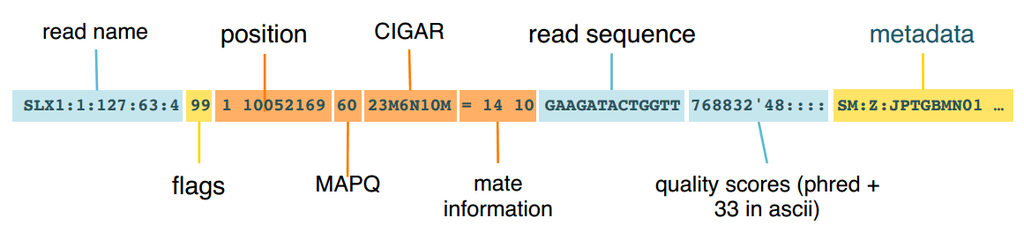

SAM records

```r
注释行部分：以@开头进行注释。如：
@HD 说明符合标准的版本、对比序列的排列顺序
@SQ 参考序列的说明
@PG 使用的比对程序
@LN 参考序列的长度

比对结果部分
column 1: query name, 比对片段的编号
column 2: FLAG，表明比对的情况
column 3：比对上的染色体号
column 4：POS，比对上的位置
column 5：MAPQ，比对的质量
column 6：CIGAR，Concise IdiosyncraRc Gapped Alignment Report. 记录插入，删除，错配以及splice junctions（后剪切拼接的接头）
column 7：MRNM，chr，下一个片段比对上的参考序列的编号
column 8：mate pos，下一个片段比对上的位置
column 9：ISIZE，模版的长度
column 10：序列片段的序列信息，read序列
column 11：read质量
column 12：程序用的标记，可选区域

# sam to bam
samtools view -bS input.sam > output.bam
```

## GTF/GFF格式

GTF和GFF是用来存储基因和基因组注释信息的文件格式，共有9列信息。  
其中，GFF的type必需注明，attribute的名称和值要以空格分开。  
GTF的attribute则是以‘=’分开。  
我们可以使用cufflinks、gffread、gff2gtf对二者进行转换。

[该格式文件的下载方法](https://zhuanlan.zhihu.com/p/36065699)

| 格式 | 列1 | 列2 | 列3 | 列4 | 列5 | 列6 | 列7 | 列8 | 列9 |
| --- | --- | --- | --- | --- | --- | --- | --- | --- | --- |
| GFF | seqID | source | type | start | end | score | strand | phase | attributes |
| GTF | seqName | souce | start | end | feature | score | strand | frame | attrbuites |

## Bigwig/wiggle

- wiggle track format(wig): http://genome.ucsc.edu/goldenPath/help/wiggle.html
- bigwig track format(bigwig): http://genome.ucsc.edu/goldenPath/help/bigWig.html
- bedgraph track format(bdg): http://genome.ucsc.edu/goldenPath/help/bedgraph.html

wig,bigwig,bedgraph 格式文件的作用是追踪参考基因组的各个区域的覆盖度,测序深度, 可以上传到UCSC的genome browser进行可视化.bigwig是wig的二进制版本. 下方是一个wig文件的示例,它只会在前面标明当前染色体一次(chrom=chr1), 测序深度统计的区间间隔是10.  
bedgraph是对bed文件的拓展, 是只有4列的BED格式,不过有额外的属性关键字.值得注意的是, bedgraph文件里面的染色体坐标是从0开始的, 坐标终点是个开区间.

对于wig,bw,bdg,gtf,gff等各种文件的转换,可以使用[这个网站](http://barcwiki.wi.mit.edu/wiki/SOPs/coordinates)的脚本.如果是SE的比对文件,可以直接使用下面的命令. 在UCSC的ftp站点中也可以直接下载这类格式的文件.

```bash
# sample.wig
track type=print wiggle_0 name=hek  description=hek
variableStep chrom=chr1 span=10
10008    7
10018    14
10028    27

# sample.bedgraph
track type=bedGraph name="hek_treat_all" description="Extended tag pileup from MACS version 1.4.2 20120305"
chr1    9997    9999    1
chr1    9999    10000   2
chr1    10000   10001   4
```

### wig,bigwig,bdg的常见转换工具

```bash
# SE.bam to bdg
macs2 pileup --extsize 200 -i sample.bam -o sample.bdg

bigwigToBedGraph
bigWigToWig
bigWigSummary
bigWigAverageOverBed
bigWigInfo
```

## VCF格式

vcf(variant calling format)格式文件用来存储与突变相关的信息。它由两部分组成。  
第一部分：头行（vcf header）,以##开头，有文件格式，使用软件信息，参考序列信息，重叠群（contig）的相关信息（拼接时reads之间的overlap区域）等等。  
第二部分：具体的突变信息，共有**八列**。

```r
1 CHROM     染色体名称（chromosome）,哪一个参考序列上发现了突变，如MAL1
2 POS       参考基因组上发生突变的位置，以1开始计算，如265854
3 ID        突变的ID,如果在dbSNP中有该SNP的id,则给出;否则为'.',表示是新的variant
4 REF       参考序列上的碱基, 必需是ATCGN之一,N表示不确定.
5 ALT       与参考碱基相比,发生突变的碱基.如REF是G, 而这里是C
6 QUAL      发生突变的碱基质量, 质量越高则是真实variant的可能性越大.如6.2.
7 FILTER    过滤后的状态,如果variant通过GATK的过滤,值为pass.
8 INFO      variant的详细信息

详细信息含：
DP          该位置的read覆盖度(reads有经过过滤)
MQ          比对到该位置reads质量值的均方值(RMS Mapping Quality)
FQ          质量值,表征所有样本相似的可能性
AF1         AF1/2表示等位基因发生频率的可能性评估,1为第一个等位基因的频率
AC1         AC1/2表示等位基因出现数目的可能性评估
AN          等位基因的总数目
IS          插入缺失或部分插入缺失的reads所允许的最大数目
INDEL       表明这个variant是插入缺失
QBD         测序深度对碱基质量的影响
其他(http://www.bio-info-trainee.com/863.html)
```